# In-cabin Sensing Overview

# Summary

Leverage our scalable portfolio of 60GHz mmWave radar sensors to enable high accuracy sensing of occupants inside a vehicle for child presence detection, seat belt reminder and intruder detection.

# Applications

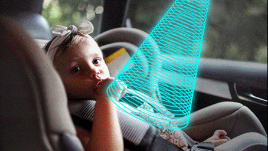

**Child Presence Detection**

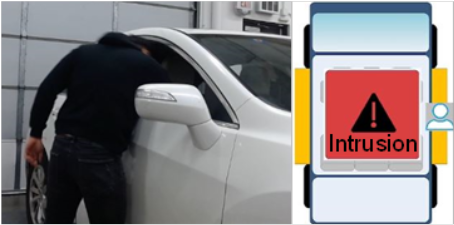

**Intrusion Detection**

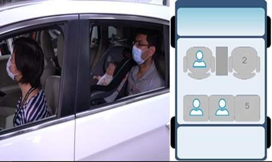

**Seat Belt Reminder**

**Function**  
Detection of children left behind in car-seat or in vehicle footwells (Euro - NCAP)

**Function**  
Continuous monitoring of vehicle surroundings for intrusion detection - Ultrasonic replacement

**Function**  
Localization of adults and children within vehicle to replace in-seat weight sensors

Recommended Devices:  
AWRL6432 (Low cost option)  
AWR6843 / AWR6443

Recommended Devices:  
AWRL6432 (Low power option - <10mW)  
AWR6843 / AWR6443

# Getting Started with mmWave for Automotive In-Cabin Radar Sensing

## Featured Demonstration Videos

Video Topic

Preview

[**3 row child presence detection and localization for seat belt reminder using AWR6843AOP**](https://training.ti.com/cabin-sensing-child-detection-3-rows-using-60ghz-radar-sensor)

[video not shown]

[**2 row child presence detection with adult vs child classification**](https://training.ti.com/ti-mmwave-sensors-automotive-cabin-occupancy-detection)

[video not shown]

[**6 person bus occupancy detection and localization using AWR6843AOP**](https://training.ti.com/6-person-occupancy-detection-using-ti-mmwave-cabin-automotive-spaces)

[video not shown]

[**Discussion with the Experts: Automotive In-Cabin Sensing**](https://training.ti.com/discussion-experts-automotive-cabin-sensing)

[video not shown]

## Development Resources

### Example Projects and Reference Designs

- Example Project -AWR6843 High Accuracy Localization Demo with Classification
- Example Project -AWRL6432 Life Presence Detection Demo
- Example Project -AWRL6432 Vehicle Intruder Detection Demo

### Certification

- [TI mmWave Radar Device Regulatory Compliance Guide](http://www.ti.com/lit/spracp3)
- TI mmWave Certification Database

### Functional Safety

- [TI mmWave Functional Safety Enablers](http://www.ti.com/lit/sprt747)
- [Understanding Functional Safety in Automotive and Industrial Applications](https://e2e.ti.com/blogs_/b/process/posts/understanding-the-importance-of-functional-safety-in-automotive-and-industrial-sensing-applications)

### Technical Resources

- [3 ways radar technology is changing the in-cabin sensing market](https://e2e.ti.com/blogs_/b/behind_the_wheel/posts/3-ways-radar-technology-is-changing-the-in-cabin-sensing-market)